# Triveni_Final_Project

```
       sepal_length  sepal_width  petal_length  petal_width
count    150.000000   150.000000    150.000000   150.000000
mean       5.843333     3.057333      3.758000     1.199333
std        0.828066     0.435866      1.765298     0.762238
min        4.300000     2.000000      1.000000     0.100000
25%        5.100000     2.800000      1.600000     0.300000
50%        5.800000     3.000000      4.350000     1.300000
75%        6.400000     3.300000      5.100000     1.800000
max        7.900000     4.400000      6.900000     2.500000
sepal_length    0.817941
sepal_width    -0.366126
petal_length    0.962865
Name: petal_width, dtype: float64
setosa        50
versicolor    50
virginica     50
Name: species, dtype: int64
Randomly picked 20 samples:
     sepal_length  sepal_width  petal_length  petal_width     species
14            5.8          4.0           1.2          0.2      setosa
98            5.1          2.5           3.0          1.1  versicolor
75            6.6          3.0           4.4          1.4  versicolor
16            5.4          3.9           1.3          0.4      setosa
131           7.9          3.8           6.4          2.0   virginica
56            6.3          3.3           4.7          1.6  versicolor
141           6.9          3.1           5.1          2.3   virginica
44            5.1          3.8           1.9          0.4      setosa
29            4.7          3.2           1.6          0.2      setosa
120           6.9          3.2           5.7          2.3   virginica
94            5.6          2.7           4.2          1.3  versicolor
5             5.4          3.9           1.7          0.4      setosa
102           7.1          3.0           5.9          2.1   virginica
51            6.4          3.2           4.5          1.5  versicolor
78            6.0          2.9           4.5          1.5  versicolor
42            4.4          3.2           1.3          0.2      setosa
92            5.8          2.6           4.0          1.2  versicolor
66            5.6          3.0           4.5          1.5  versicolor
31            5.4          3.4           1.5          0.4      setosa
35            5.0          3.2           1.2          0.2      setosa
```

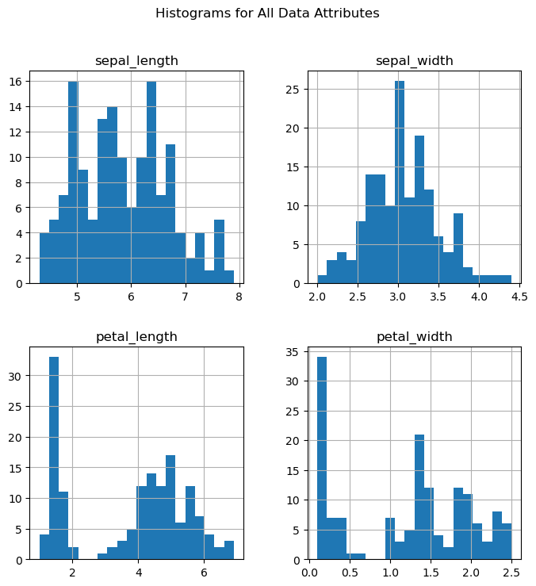

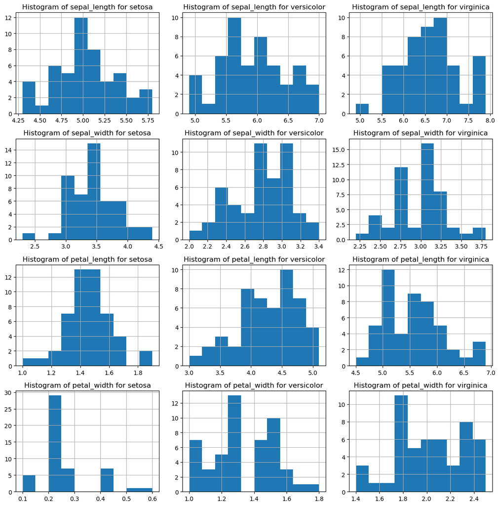

```
Mean after dropping NaN rows:
sepal_length    5.843333
sepal_width     3.057333
petal_length    3.758000
petal_width     1.199333
dtype: float64

Variance after dropping NaN rows:
sepal_length    0.685694
sepal_width     0.189979
petal_length    3.116278
petal_width     0.581006
dtype: float64

Correlation between col4 and col1: 1.0
Correlation between col4 and col2: 1.0
Correlation between col4 and col3: 1.0
Index(['class', 'value'], dtype='object')
class
A    30.0
B    40.0
Name: value, dtype: float64

Randomly picked 20 samples:
  class  value
3     B     40
5     B     60
4     A     50
4     A     50
0     A     10
1     B     20
1     B     20
1     B     20
2     A     30
3     B     40
4     A     50
4     A     50
2     A     30
2     A     30
0     A     10
0     A     10
4     A     50
5     B     60
0     A     10
1     B     20
```

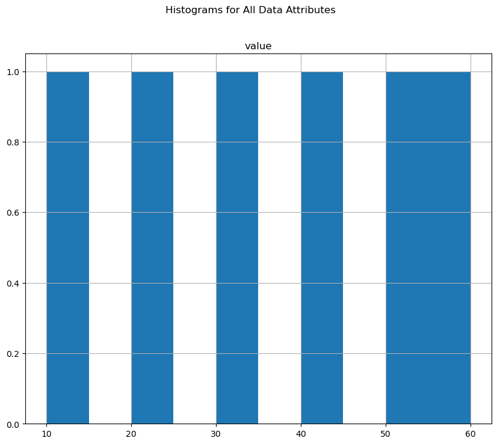

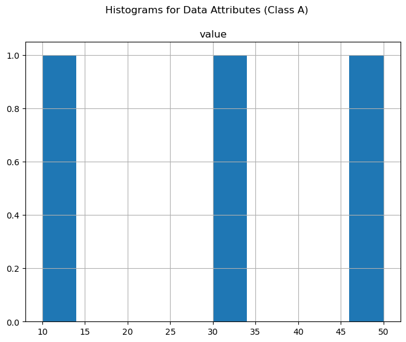

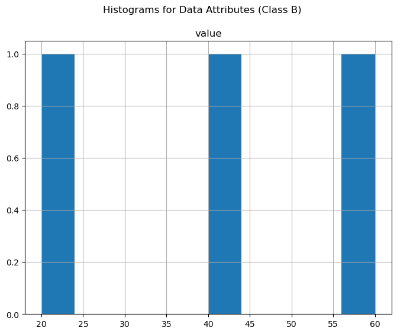

```python
## Solve Here
import numpy as np
import pandas as pd
import matplotlib.pyplot as plt
import seaborn as sns

# Load iris dataset
df = sns.load_dataset('iris')

# Summary statistics
print(df.describe())

# Correlation with Petal Width
print(df.corr()['petal_width'].drop('petal_width'))

# Count of classes
print(df['species'].value_counts())

# Sample 20 random rows
random_samples = df.sample(20, random_state=1)
print("Randomly picked 20 samples:")
print(random_samples)

# Histogram for each feature
df.hist(bins=20, figsize=(8, 8))
plt.suptitle("Histograms for All Data Attributes")
plt.show()

# Subplot histogram per species per feature
features = df.columns[:-1] # exclude species
species = df['species'].unique()
fig, axarr = plt.subplots(len(features), len(species), figsize=(12, 12))

for i, f in enumerate(features):
    for j, s in enumerate(species):
        df[df['species']==s][f].hist(ax=axarr[i, j])
        axarr[i, j].set_title(f"Histogram of {f} for {s}")

fig.tight_layout()
plt.show()

# Drop NaN rows
df = df.dropna()

# Recalculate mean and variance
print("\nMean after dropping NaN rows:")
print(df.mean(numeric_only=True))
print("\nVariance after dropping NaN rows:")
print(df.var(numeric_only=True))

# Create a sample DataFrame
data = {'col1': [1, 2, 3, 4],
        'col2': [5, 6, 7, 8],
        'col3': [9, 10, 11, 12],
        'col4': [13, 14, 15, 16]}

df_sample = pd.DataFrame(data)

# Perform correlation calculations
correlation_col4_col1 = df_sample['col4'].corr(df_sample['col1'])
correlation_col4_col2 = df_sample['col4'].corr(df_sample['col2'])
correlation_col4_col3 = df_sample['col4'].corr(df_sample['col3'])

print("\nCorrelation between col4 and col1:", correlation_col4_col1)
print("Correlation between col4 and col2:", correlation_col4_col2)
print("Correlation between col4 and col3:", correlation_col4_col3)

# Example DataFrame
data_class = {
    'class': ['A', 'B', 'A', 'B', 'A', 'B'],
    'value': [10, 20, 30, 40, 50, 60]
}

df_class = pd.DataFrame(data_class)

# Check DataFrame columns
print(df_class.columns)

# Check if 'class' column exists
if 'class' in df_class.columns:
    # Assuming 'value' is the numeric column you want to aggregate
    # Example: Calculate the mean value for each class
    result = df_class.groupby('class')['value'].mean()
    print(result)
else:
    print("Column 'class' not found.")

# Set random seed to 1234
np.random.seed(1234)

# Randomly pick 20 samples
try:
    random_samples_class = df_class.sample(20, replace=True)
    print("\nRandomly picked 20 samples:")
    print(random_samples_class)
except ValueError as e:
    print(f"Sampling error: {e}")

# Plot histogram for all data attributes
df_class.hist(figsize=(10, 8))
plt.suptitle("Histograms for All Data Attributes")
plt.show()

# Group by class and plot histograms
for class_label, class_data in df_class.groupby('class'):
    class_data.hist(figsize=(8, 6))
    plt.suptitle(f"Histograms for Data Attributes (Class {class_label})")
    plt.show()
```

```python
df
```

|  | sepal_length | sepal_width | petal_length | petal_width | species |
| --- | --- | --- | --- | --- | --- |
| 0 | 5.1 | 3.5 | 1.4 | 0.2 | setosa |
| 1 | 4.9 | 3.0 | 1.4 | 0.2 | setosa |
| 2 | 4.7 | 3.2 | 1.3 | 0.2 | setosa |
| 3 | 4.6 | 3.1 | 1.5 | 0.2 | setosa |
| 4 | 5.0 | 3.6 | 1.4 | 0.2 | setosa |
| ... | ... | ... | ... | ... | ... |
| 145 | 6.7 | 3.0 | 5.2 | 2.3 | virginica |
| 146 | 6.3 | 2.5 | 5.0 | 1.9 | virginica |
| 147 | 6.5 | 3.0 | 5.2 | 2.0 | virginica |
| 148 | 6.2 | 3.4 | 5.4 | 2.3 | virginica |
| 149 | 5.9 | 3.0 | 5.1 | 1.8 | virginica |

150 rows × 5 columns

- Use Scipy pdf fitting to do a curve fitting for the petal-length
- Plot the normalized histogrm of the petal-length and the estimated pdf on the same figure
- Generate new 500 samples using the estimated pdf for the petal-length
- Calculate the mean of the new samples and compare how close it is to the mean of the given data

```
Orig mean: 3.76
New mean: 3.76
```

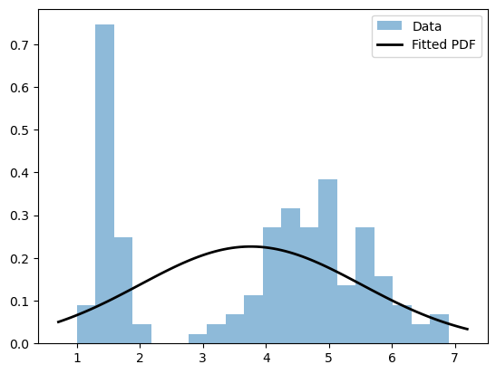

```python
##Solve here
import pandas as pd
from scipy.stats import norm
import matplotlib.pyplot as plt
import seaborn as sns

# Load iris data
#df = sns.load_dataset('iris')

# Plot histogram
plt.hist(df['petal_length'], density=True, bins=20, alpha=0.5, label='Data')

# Fit distribution
mu, std = norm.fit(df['petal_length'])

# Plot the estimated PDF
xmin, xmax = plt.xlim()
x = np.linspace(xmin, xmax, 100)
p = norm.pdf(x, mu, std)
plt.plot(x, p, 'k', linewidth=2, label='Fitted PDF')

# Generate new samples
new_samples = np.random.normal(mu, std, 500)
new_samples_mean = new_samples.mean()

print(f"Orig mean: {df['petal_length'].mean():.2f}")
print(f"New mean: {new_samples_mean:.2f}")

plt.legend()
plt.show()
```

```python
df
```

|  | sepal_length | sepal_width | petal_length | petal_width | species |
| --- | --- | --- | --- | --- | --- |
| 0 | 5.1 | 3.5 | 1.4 | 0.2 | setosa |
| 1 | 4.9 | 3.0 | 1.4 | 0.2 | setosa |
| 2 | 4.7 | 3.2 | 1.3 | 0.2 | setosa |
| 3 | 4.6 | 3.1 | 1.5 | 0.2 | setosa |
| 4 | 5.0 | 3.6 | 1.4 | 0.2 | setosa |
| ... | ... | ... | ... | ... | ... |
| 145 | 6.7 | 3.0 | 5.2 | 2.3 | virginica |
| 146 | 6.3 | 2.5 | 5.0 | 1.9 | virginica |
| 147 | 6.5 | 3.0 | 5.2 | 2.0 | virginica |
| 148 | 6.2 | 3.4 | 5.4 | 2.3 | virginica |
| 149 | 5.9 | 3.0 | 5.1 | 1.8 | virginica |

150 rows × 5 columns

### PCA

- Use Scikit to do PCA on the IRIS dataset
- do a bar plot that shows the importance of info in each of the new dimensions
- use PCA to reduce the number of attributes by 1. Note that for all the next parts, you will use the reduced data

```
(150, 3)
```

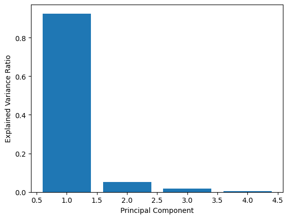

```python
# Solve Here
from sklearn.decomposition import PCA
from sklearn.datasets import load_iris
import matplotlib.pyplot as plt

# Load the Iris datasets
iris = load_iris()
X = iris.data

# Create the PCA model and fit it
pca = PCA(n_components=4)
pca.fit(X)

# Transform the data
X_reduced = pca.transform(X)

# Plot the explained variance ratio per component
explained_variance = pca.explained_variance_ratio_
plt.bar([1, 2, 3, 4], explained_variance)
plt.xlabel('Principal Component')
plt.ylabel('Explained Variance Ratio')

# Reduce number of components by 1
pca = PCA(n_components=3)
X_reduced = pca.fit_transform(X)
print(X_reduced.shape)
```

# Part 4: Machine Learning

In this part, you will explore the use of supervised and non supervised learning. If you have done part 3, use the data outcome of the PCA. Otherwise, use the original data.

### Non-Supervised Learning

- using Kmeans, divide the data into different clusters. The number of clusters should be the same as the number of categories you have in the data
- Do scatter plot for each two combination of the three dimensions together (0 vs 1), (0 vs 2), (1 vs 2). Use the kmeans labels to color the points in the scatter plots

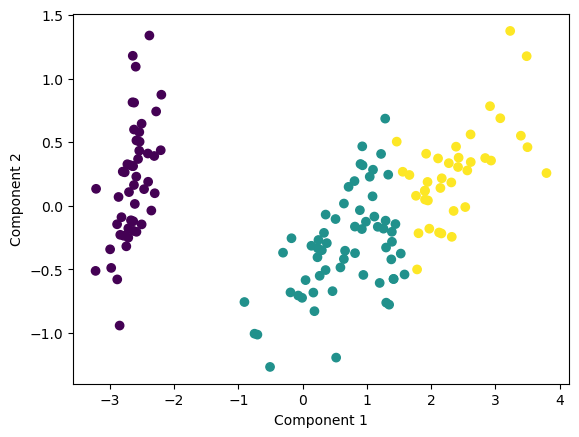

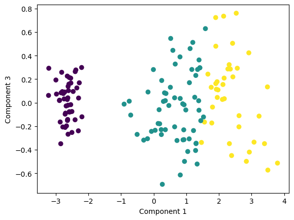

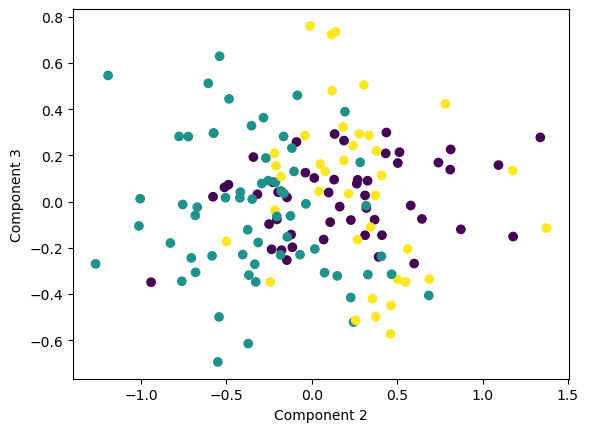

```python
# Solve Here
from sklearn.decomposition import PCA
from sklearn.cluster import KMeans
import matplotlib.pyplot as plt
import numpy as np

# Assuming you have a dataset named X (replace this with your actual dataset)
# For example, X = your_data

# Perform PCA
pca = PCA(n_components=3)
X_reduced = pca.fit_transform(X)

# Create KMeans model
kmeans = KMeans(n_clusters=3)

# Fit model
kmeans.fit(X_reduced)

# Get cluster labels
labels = kmeans.labels_

# Plot 0 vs 1
plt.scatter(X_reduced[:, 0], X_reduced[:, 1], c=labels)
plt.xlabel('Component 1')
plt.ylabel('Component 2')
plt.show()

# Plot 0 vs 2
plt.scatter(X_reduced[:, 0], X_reduced[:, 2], c=labels)
plt.xlabel('Component 1')
plt.ylabel('Component 3')
plt.show()

# Plot 1 vs 2
plt.scatter(X_reduced[:, 1], X_reduced[:, 2], c=labels)
plt.xlabel('Component 2')
plt.ylabel('Component 3')
plt.show()

plt.show()
```

### Supervised-Learning

- Divide your dataset to 80% training and 20% validation
- Build a Logistci regression model for the reduced IRIS dataset
- What is the training accuracy
- What is the validation accuracy
- Form the confusion matrix

```python
# Solve Here
from sklearn.model_selection import train_test_split
from sklearn.linear_model import LogisticRegression
from sklearn.metrics import accuracy_score, confusion_matrix
from sklearn.datasets import load_iris
from sklearn.decomposition import PCA
from sklearn.cluster import KMeans

# Load Iris dataset
iris = load_iris()
X = iris.data
y = iris.target

# Assume you have performed PCA and KMeans clustering on X, and y represents the cluster labels
# You should replace the following lines with your actual PCA and KMeans code
# X_reduced = ...
# kmeans = KMeans(n_clusters=3)
# y = kmeans.fit_predict(X_reduced)

# Split the data into train and validate
X_train, X_valid, y_train, y_valid = train_test_split(X, y, test_size=0.2, random_state=42)

# Train logistic regression model with increased max_iter
logreg = LogisticRegression(max_iter=1000)  # You can adjust the number of iterations as needed
logreg.fit(X_train, y_train)

# Evaluate on the training set
y_pred_train = logreg.predict(X_train)
train_accuracy = accuracy_score(y_train, y_pred_train)
print(f"Training accuracy: {train_accuracy:.3f}")

# Evaluate on the validation set
y_pred_valid = logreg.predict(X_valid)
validation_accuracy = accuracy_score(y_valid, y_pred_valid)
print(f"Validation accuracy: {validation_accuracy:.3f}")

# Create and print confusion matrix
conf_mat = confusion_matrix(y_valid, y_pred_valid)
print("Confusion Matrix:\n", conf_mat)
```

```
Training accuracy: 0.975
Validation accuracy: 1.000
Confusion Matrix:
 [[10  0  0]
 [ 0  9  0]
 [ 0  0 11]]
```